# Part 2 — Logistic Regression from Scratch - PDAN8412

### ST10458509 - Rick Jackson

Top Goodreads Books Collection (1980–2023) dataset

www.kaggle.com/datasets/jealousleopard/goodreadsbooks

### Import Libraries

```python
import pandas as pd
import numpy as np
import matplotlib.pyplot as plt
import seaborn as sns

from sklearn.model_selection import train_test_split
from sklearn.metrics import accuracy_score
from sklearn.preprocessing import StandardScaler
from sklearn.metrics import precision_score, recall_score, f1_score, classification_report, confusion_matrix
```

```python
# Load dataset (update file path as needed)
df = pd.read_csv('goodreads_top100_from1980to2023_final.csv')
```

```python
# Preview the first few rows
df.head()
```

|  | Unnamed: 0 | isbn | title | series_title | series_release_number | authors | publisher | language | description | num_pages | format | genres | publication_date | rating_score | num_ratings | num_reviews | current_readers | want_to_read | price | url |
| --- | --- | --- | --- | --- | --- | --- | --- | --- | --- | --- | --- | --- | --- | --- | --- | --- | --- | --- | --- | --- |
| 0 | 0 | 9780689830594 | Summer Story | Brambly Hedge | 2 | Jill Barklem | Atheneum | English | It was such a hot summer. The sky was deep blu... | 32 | Hardcover | ['Picture Books', 'Childrens', 'Fiction', 'Ani... | January 1, 1980 | 4.45 | 1017.0 | 74.0 | 7.0 | 512.0 | 3.49 | https://www.goodreads.com/book/show/421572.Sum... |
| 1 | 1 | 9780375704970 | The Lake of Darkness | NaN | NaN | Ruth Rendell | Vintage Crime/Black Lizard | English | Martin Urban is a quiet bachelor with a comfor... | 210 | Paperback | ['Mystery', 'Fiction', 'Crime', 'Thriller', 'B... | January 1, 1980 | 3.76 | 1388.0 | 114.0 | 77.0 | 623.0 | 4.99 | https://www.goodreads.com/book/show/83394.The_... |
| 2 | 2 | 9780345446671 | Beyond the Blue Event Horizon | Heechee Saga | 2 | Frederik Pohl | Ballantine Books | English | In Book Two of the Heechee Saga, Robinette Bro... | 336 | Paperback | ['Science Fiction', 'Fiction', 'Space Opera', ... | January 1, 1980 | 3.95 | 13307.0 | 339.0 | 181.0 | 3961.0 | 11.99 | https://www.goodreads.com/book/show/373399.Bey... |
| 3 | 3 | 9780446403016 | St. Peter's Fair | Chronicles of Brother Cadfael | 4 | Ellis Peters | Mysterious Press | English | A pause in the civil war offers Shrewsbury's t... | 217 | Mass Market Paperback | ['Mystery', 'Historical Fiction', 'Fiction', '... | May 1, 1981 | 4.12 | 10493.0 | 593.0 | 1298.0 | 2502.0 | 0.00 | https://www.goodreads.com/book/show/751755.St_... |
| 4 | 4 | 9780425198773 | Twice Shy | NaN | NaN | Dick Francis | G.P. Putnam's Sons | English | A computerized horse-betting system falls into... | 304 | Mass Market Paperback | ['Mystery', 'Fiction', 'Thriller', 'Crime', 'S... | January 1, 1981 | 3.92 | 4188.0 | 174.0 | 162.0 | 642.0 | 8.99 | https://www.goodreads.com/book/show/103250.Twi... |

```python
# Checking data structure
df.info()
```

```
<class 'pandas.core.frame.DataFrame'>
RangeIndex: 4400 entries, 0 to 4399
Data columns (total 20 columns):
 #   Column                 Non-Null Count  Dtype
---  ------                 --------------  -----
 0   Unnamed: 0             4400 non-null   int64
 1   isbn                   3806 non-null   object
 2   title                  4400 non-null   object
 3   series_title           2268 non-null   object
 4   series_release_number  2256 non-null   object
 5   authors                4400 non-null   object
 6   publisher              4284 non-null   object
 7   language               4374 non-null   object
 8   description            4398 non-null   object
 9   num_pages              4379 non-null   object
 10  format                 4365 non-null   object
 11  genres                 4400 non-null   object
 12  publication_date       4399 non-null   object
 13  rating_score           4400 non-null   float64
 14  num_ratings            4400 non-null   float64
 15  num_reviews            4400 non-null   float64
 16  current_readers        4296 non-null   float64
 17  want_to_read           4361 non-null   float64
 18  price                  4167 non-null   float64
 19  url                    4400 non-null   object
dtypes: float64(6), int64(1), object(13)
memory usage: 687.6+ KB
```

```python
# Checking for missing values
df.isnull().sum()
```

```
Unnamed: 0                  0
isbn                      594
title                       0
series_title             2132
series_release_number    2144
authors                     0
publisher                 116
language                   26
description                 2
num_pages                  21
format                     35
genres                      0
publication_date            1
rating_score                0
num_ratings                 0
num_reviews                 0
current_readers           104
want_to_read               39
price                     233
url                         0
dtype: int64
```

While the dataset is regarded as "clean", there are still a bit of missing values. There are columns present with missing values which does not affect the final result and will be dropped.

**Column Drop**

```python
# Drop columns not needed or mostly missing
df = df.drop(columns=['isbn', 'series_title', 'series_release_number', 'url'])

df.head()
```

|  | Unnamed: 0 | title | authors | publisher | language | description | num_pages | format | genres | publication_date | rating_score | num_ratings | num_reviews | current_readers | want_to_read | price |
| --- | --- | --- | --- | --- | --- | --- | --- | --- | --- | --- | --- | --- | --- | --- | --- | --- |
| 0 | 0 | Summer Story | Jill Barklem | Atheneum | English | It was such a hot summer. The sky was deep blu... | 32 | Hardcover | ['Picture Books', 'Childrens', 'Fiction', 'Ani... | January 1, 1980 | 4.45 | 1017.0 | 74.0 | 7.0 | 512.0 | 3.49 |
| 1 | 1 | The Lake of Darkness | Ruth Rendell | Vintage Crime/Black Lizard | English | Martin Urban is a quiet bachelor with a comfor... | 210 | Paperback | ['Mystery', 'Fiction', 'Crime', 'Thriller', 'B... | January 1, 1980 | 3.76 | 1388.0 | 114.0 | 77.0 | 623.0 | 4.99 |
| 2 | 2 | Beyond the Blue Event Horizon | Frederik Pohl | Ballantine Books | English | In Book Two of the Heechee Saga, Robinette Bro... | 336 | Paperback | ['Science Fiction', 'Fiction', 'Space Opera', ... | January 1, 1980 | 3.95 | 13307.0 | 339.0 | 181.0 | 3961.0 | 11.99 |
| 3 | 3 | St. Peter's Fair | Ellis Peters | Mysterious Press | English | A pause in the civil war offers Shrewsbury's t... | 217 | Mass Market Paperback | ['Mystery', 'Historical Fiction', 'Fiction', '... | May 1, 1981 | 4.12 | 10493.0 | 593.0 | 1298.0 | 2502.0 | 0.00 |
| 4 | 4 | Twice Shy | Dick Francis | G.P. Putnam's Sons | English | A computerized horse-betting system falls into... | 304 | Mass Market Paperback | ['Mystery', 'Fiction', 'Thriller', 'Crime', 'S... | January 1, 1981 | 3.92 | 4188.0 | 174.0 | 162.0 | 642.0 | 8.99 |

Columns like format, language and publisher aren't missing too many fields overall but is required for the analysis. These columns will be filled in with 'unknown' to ensure there are no breaks.

### Filling Columns with missing values, replacing as 'unknown'

```python
# Fill small numeric gaps with median values

# df['num_pages'] = df['num_pages'].fillna(df['num_pages'].median())

# df['price'] = df['price'].fillna(df['price'].median())

# df['current_readers'] = df['current_readers'].fillna(df['current_readers'].median())

# df['want_to_read'] = df['want_to_read'].fillna(df['want_to_read'].median())
```

[output not shown]

Code inspection to see what the dataset is containing instead of the 'expected' numerical values.

```python
# Checking what num_pages column contains
df['num_pages'].sample(10)
```

```
1683    325
2081    370
2562    312
2705    566
1453    251
622     688
2339    326
1441    256
2785    280
2832     40
Name: num_pages, dtype: object
```

```python
# Checking what price column contains
df['price'].sample(10)
```

```
3298    11.99
123      8.99
1851      NaN
3111     6.99
3100    10.99
3234    10.99
1844     4.99
641     10.99
729      1.99
1610    12.99
Name: price, dtype: float64
```

```python
df['current_readers'].sample(10)
```

```
1532     2406.0
3231    15800.0
1396      214.0
2043      985.0
4398     4485.0
3756     6928.0
4304      405.0
3933     7426.0
965       511.0
1808     1672.0
Name: current_readers, dtype: float64
```

```python
df['want_to_read'].sample(10)
```

```
2754     34200.0
1757     11800.0
674        274.0
1544     24000.0
1533     11500.0
1760      2333.0
3918    243000.0
3311     38400.0
3123     93200.0
607      30100.0
Name: want_to_read, dtype: float64
```

```python
df[['num_pages', 'price', 'current_readers' ,'want_to_read']].dtypes
```

```
num_pages           object
price              float64
current_readers    float64
want_to_read       float64
dtype: object
```

**Cleaning the 'num_pages' column**

```python
# Handling all values as though they were string.

df['num_pages'] = df['num_pages'].astype(str)
```

```python
# Checking whether conversion is successful from object

df['num_pages'].apply(type).value_counts()
```

```
num_pages
<class 'str'>    4400
Name: count, dtype: int64
```

```python
# Extracting digits only from the converted string text

df['num_pages_digits'] = df['num_pages'].str.extract(r'(\d+)')
```

```python
df[['num_pages', 'num_pages_digits']].head(10)
```

|  | num_pages | num_pages_digits |
| --- | --- | --- |
| 0 | 32 | 32 |
| 1 | 210 | 210 |
| 2 | 336 | 336 |
| 3 | 217 | 217 |
| 4 | 304 | 304 |
| 5 | 216 | 216 |
| 6 | 14 | 14 |
| 7 | 304 | 304 |
| 8 | 288 | 288 |
| 9 | 111 | 111 |

```python
# Safely converting the new column into a numeric dtype

df['num_pages_digits'] = pd.to_numeric(df['num_pages_digits'], errors='coerce')
```

```python
# Checking data type

df['num_pages_digits'].info()
```

```
<class 'pandas.core.series.Series'>
RangeIndex: 4400 entries, 0 to 4399
Series name: num_pages_digits
Non-Null Count  Dtype
--------------  -----
4379 non-null   float64
dtypes: float64(1)
memory usage: 34.5 KB
```

```python
# Handling Missing Values for 'num_pages_digits' and filling it with median values

median_pages = df['num_pages_digits'].median()

df['num_pages_digits'] = df['num_pages_digits'].fillna(median_pages)
```

```python
# Replacing the cleaned 'num_pages_digits column and then making the 'num-pages' column

df['num_pages'] = df['num_pages_digits']

df = df.drop(columns=['num_pages_digits'])
```

```python
print(df['num_pages'].dtype)

df['num_pages'].describe()
```

```
float64
```

```
count    4400.000000
mean      376.328182
std       173.757854
min         2.000000
25%       285.750000
50%       353.000000
75%       440.000000
max      1859.000000
Name: num_pages, dtype: float64
```

The above steps will now be performed on the required columns. They will all be dealt with in the same fashion as above to ensure the safe conversion of values as well as handle missing values.

**Cleaning the 'price' column**

```python
# Converting all entries to strings in the event some entries are text

df['price'] = df['price'].astype(str)
```

```python
# Removing currency symbols or commas if present, $ used because the dataset is based on an American audience.

df['price_clean'] = df['price'].str.replace(r'[\$,]', '', regex=True)
```

```python
# Converting to numeric

df['price_clean'] = pd.to_numeric(df['price_clean'], errors='coerce')
```

```python
# Filling in the missing values with median

df['price_clean'] = df['price_clean'].fillna(df['price_clean'].median())
```

```python
# Replacing the original column now containing the column in the required field format

df['price'] = df['price_clean']

df = df.drop(columns=['price_clean'])
```

```python
print(df['price'].dtype)

df['price'].describe()
```

```
float64
```

```
count    4400.000000
mean        8.890384
std         4.392448
min         0.000000
25%         6.990000
50%         9.990000
75%        11.990000
max        29.990000
Name: price, dtype: float64
```

**Cleaning the 'current_readers' column**

```python
# Converting all entries to strings (in case some are text)

df['current_readers'] = df['current_readers'].astype(str)
```

```python
# Converting to numeric

df['current_readers'] = pd.to_numeric(df['current_readers'], errors='coerce')
```

```python
# Filling in the missing fields with median values

df['current_readers'] = df['current_readers'].fillna(df['current_readers'].median())
```

```python
print(df['current_readers'].dtype)

df['current_readers'].describe()
```

```
float64
```

```
count      4400.000000
mean       5215.143182
std       12504.504533
min           2.000000
25%         404.000000
50%        1240.000000
75%        4095.750000
max      224000.000000
Name: current_readers, dtype: float64
```

```python
# Converting all entries to strings (in case some are text)

df['want_to_read'] = df['want_to_read'].astype(str)
```

```python
# Step 4a: Convert to numeric

df['want_to_read'] = pd.to_numeric(df['want_to_read'], errors='coerce')
```

```python
# Step 4b: Fill missing with median

df['want_to_read'] = df['want_to_read'].fillna(df['want_to_read'].median())
```

```python
print(df['want_to_read'].dtype)

df['want_to_read'].describe()
```

```
float64
```

```
count    4.400000e+03
mean     8.865130e+04
std      1.715564e+05
min      3.000000e+00
25%      6.952500e+03
50%      2.400000e+04
75%      9.222500e+04
max      2.000000e+06
Name: want_to_read, dtype: float64
```

**Confirming the results of the conversion**

```python
df[['num_pages', 'price', 'current_readers', 'want_to_read']].info()
```

```
<class 'pandas.core.frame.DataFrame'>
RangeIndex: 4400 entries, 0 to 4399
Data columns (total 4 columns):
 #   Column           Non-Null Count  Dtype
---  ------           --------------  -----
 0   num_pages        4400 non-null   float64
 1   price            4400 non-null   float64
 2   current_readers  4400 non-null   float64
 3   want_to_read     4400 non-null   float64
dtypes: float64(4)
memory usage: 137.6 KB
```

```python
df[['num_pages', 'price', 'current_readers', 'want_to_read']].describe()
```

|  | num_pages | price | current_readers | want_to_read |
| --- | --- | --- | --- | --- |
| count | 4400.000000 | 4400.000000 | 4400.000000 | 4.400000e+03 |
| mean | 376.328182 | 8.890384 | 5215.143182 | 8.865130e+04 |
| std | 173.757854 | 4.392448 | 12504.504533 | 1.715564e+05 |
| min | 2.000000 | 0.000000 | 2.000000 | 3.000000e+00 |
| 25% | 285.750000 | 6.990000 | 404.000000 | 6.952500e+03 |
| 50% | 353.000000 | 9.990000 | 1240.000000 | 2.400000e+04 |
| 75% | 440.000000 | 11.990000 | 4095.750000 | 9.222500e+04 |
| max | 1859.000000 | 29.990000 | 224000.000000 | 2.000000e+06 |

**Filling missing values**

Filling missing values in the columns such as publisher/language/format with 'Unknown'

```python
# Fill missing publisher with 'Unknown'

df['publisher'] = df['publisher'].fillna('Unknown')
```

```python
# Fill missing language with 'Unknown'

df['language'] = df['language'].fillna('Unknown')
```

```python
# Fill missing format with 'Unknown'

df['format'] = df['format'].fillna('Unknown')
```

**Feature Engineering**

The dataset does not have a 'Bestseller' column. This needs to be engineered and wil be created by proxy measure 'num_ratings'. This holds the count for how many people rated the book, infering more engagement with content etc.

For this project, 'Bestseller' will be any book in the top 25% of 'num_ratings'

*Bestseller Definition:*

Bestseller (1) = book in the top 25% of num_ratings

Not bestseller (0) = all other books

The aim is to create a binary target suitable for logistic regression.

```python
# Determining the 75th percentile (top 25%)
threshold = df['num_ratings'].quantile(0.75)
```

```python
# Creating the binary bestseller column for further analysis
df['bestseller'] = (df['num_ratings'] >= threshold).astype(int)
```

```python
# Checking balance of classes
df['bestseller'].value_counts(normalize=True)
```

```
bestseller
0    0.75
1    0.25
Name: proportion, dtype: float64
```

**Visualizing the Bestseller Spilt**

Visualizing the above step, below, to determine the code so far is working correctly.

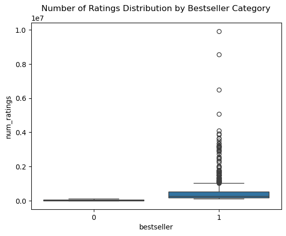

```python
sns.boxplot(x='bestseller', y='num_ratings', data=df)
plt.title('Number of Ratings Distribution by Bestseller Category')
plt.show()
```

The above result have NO circles in the non-bestseller indicates the code seems to be in workiing order.

A simple logistic regression model is built to create a benchmark result, using the 'bestseller'. feature.

**Feature Selection** to train the model:

```python
# Selecting meaningful features for the model which indicate popularity

features = ['rating_score', 'num_pages', 'price', 'current_readers', 'want_to_read']
```

```python
# For the logistic regression model, it requires X and y variables. Here the X and y value are defined

X = df[features]

y = df['bestseller']
```

Before running anything through the model, the data needs to be transformed and balanced in order to provide an accurate reading.